# Study_monocle3

jmzeng1314@163.com

24 February, 2019

## 引言

教程，当然是以官网为主，不过看英文笔记有挑战，简略带领大家一起学习咯：http://cole-trapnell-lab.github.io/monocle-release/docs/

值得注意的是这里展现的是monocle2版本的使用教程，因为monocle3仍然是不那么稳定。

## 载入必要的R包

需要自行下载安装一些必要的R包！这里就是Monocle

```r
if (!requireNamespace("BiocManager"))
    install.packages("BiocManager")
if (!requireNamespace("monocle"))
    BiocManager::install("monocle")
```

加载R包

```r
rm(list = ls()) # clear the environment
#load all the necessary libraries
options(warn=-1) # turn off warning message globally
suppressMessages(library(monocle))
```

## 创建数据集

后续分析的前提就是将数据构建成monocle需要的对象。

因此这里先介绍一下monocle需要的用来构建 CellDataSet 对象的三个数据集

- 表达量矩阵`exprs`:数值矩阵 行名是基因, 列名是细胞编号.
- 细胞的表型信息`phenoData`: 第一列是细胞编号，其他列是细胞的相关信息
- 基因注释`featureData`: 第一列是基因编号, 其他列是基因对应的信息

并且这三个数据集要满足如下要求:

表达量矩阵**必须**：

- 保证它的列数等于`phenoData`的行数
- 保证它的行数等于`featureData`的行数

而且

- `phenoData`的行名需要和表达矩阵的列名匹配
- `featureData`和表达矩阵的行名要匹配
- `featureData`至少要有一列“gene_short_name”, 就是基因的symbol

如下是几个例子

### 测试数据集

该R包团队给出的例子有点可怕。

需要使用网络公共数据，取决于网速，是浙江大学郭老师的40万小鼠单细胞转录组数据。

第一个rds文件大小接近3G，太难下载了，即使侥幸下载，一般人的电脑也没办法处理它。

下载地址:

- http://trapnell-lab.gs.washington.edu/public_share/MCA_merged_mat.rds
- http://trapnell-lab.gs.washington.edu/public_share/MCA_All-batch-removed-assignments.csv

第二个csv文件也有 26.5M

- https://www.ncbi.nlm.nih.gov/geo/query/acc.cgi?acc=GSE72857

```r
MCA <- readRDS("./MCA_merged_mat.rds")
cell.meta.data <- read.csv("./MCA_All-batch-removed-assignments.csv", row.names = 1)
```

39855 x 405191 sparse Matrix of class “dgCMatrix”

```r
 class(MCA)
## 这是一个对象，需要仔细理解，这里略
```

```r
overlapping_cells <- intersect(row.names(cell.meta.data), colnames(MCA))
gene_ann <- data.frame(gene_short_name = row.names(MCA), row.names = row.names(MCA))

pd <- new("AnnotatedDataFrame",
          data=cell.meta.data[overlapping_cells, ])
fd <- new("AnnotatedDataFrame",
          data=gene_ann)
```

下面构造了一个MCA数据集的子集，基于：overlapping_cells

```r
MCA_cds <- newCellDataSet(
  MCA[, overlapping_cells],
  phenoData = pd,
  featureData =fd,
  expressionFamily = negbinomial.size(),
  lowerDetectionLimit=1)

save(MCA_cds,file = './MCA_cds_monocle_example.Rdata')
```

全部载入后的数据在R里面如下：

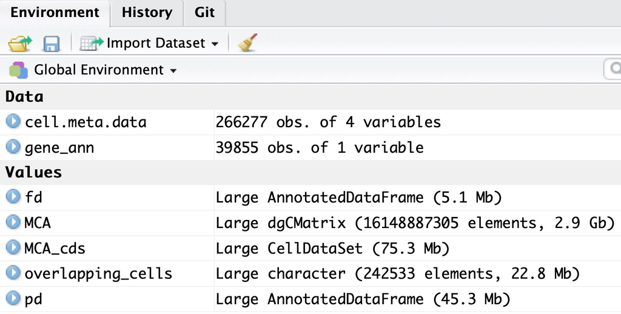

但是数据集实在是太大，我这里只能载入前面步骤保存的小数据集。

```r
## 这个文件很大，我放在了Rmd路径下面。
load(file = './MCA_cds_monocle_example.Rdata')
# 所以你们运行这个代码是没有意义的，因为这个文件MCA_cds_monocle_example.Rdata仅仅是存在于我的电脑
MCA_cds
# 是一个 CellDataSet 对象， 有着24万的单细胞，演示软件用法实在是太难
```

### scRNAseq R包中的数据集

比如我们选择 scRNAseq 这个R包。 这个包内置的是 Pollen et al. 2014 数据集，人类单细胞细胞，分成`4`类，分别是 pluripotent stem cells 分化而成的 neural progenitor cells (“NPC”) ，还有 “GW16” and “GW21” ，“GW21+3” 这种孕期细胞。

大小是50.6 MB，下载需要一点点时间，先安装加载它们。

这个数据集很出名，截止2019年1月已经有近400的引用了，后面的人开发R包算法都会在其上面做测试，比如 SinQC 这篇文章就提到：We applied SinQC to a highly heterogeneous scRNA-seq dataset containing 301 cells (mixture of 11 different cell types) (Pollen et al., 2014).

不过本例子只使用了数据集的`4种细胞类型`而已，因为 scRNAseq 这个R包就提供了这些，完整的数据是 23730 features， 301 samples 在 https://hemberg-lab.github.io/scRNA.seq.datasets/human/tissues/

这里面的表达矩阵是由 RSEM (Li and Dewey 2011) 软件根据 hg38 RefSeq transcriptome 得到的，总是130个文库，每个细胞测了两次，测序深度不一样。

```r
library(scRNAseq)
## ----- Load Example Data -----
data(fluidigm)
# Set assay to RSEM estimated counts
assay(fluidigm)  <-  assays(fluidigm)$rsem_counts
ct <- floor(assays(fluidigm)$rsem_counts)
ct[1:4,1:4]
```

```
##          SRR1275356 SRR1274090 SRR1275251 SRR1275287
## A1BG              0          0          0          0
## A1BG-AS1          0          0          0          0
## A1CF              0          0          0          0
## A2M               0          0          0         33
```

```r
sample_ann <- as.data.frame(colData(fluidigm))
```

准备Monocle对象需要的phenotype data 和 feature data 以及表达矩阵，从 scRNAseq 这个R包里面提取这三种数据。

```r
gene_ann <- data.frame(
  gene_short_name = row.names(ct),
  row.names = row.names(ct)
)

pd <- new("AnnotatedDataFrame",
          data=sample_ann)
fd <- new("AnnotatedDataFrame",
          data=gene_ann)
```

构建Monocle后续分析的所用对象，主要是根据包的说明书，仔细探索其需要的构建对象的必备元素

**注意点**: 因为表达矩阵是counts值，所以注意 expressionFamily 参数

```r
sc_cds <- newCellDataSet(
  ct,
  phenoData = pd,
  featureData =fd,
  expressionFamily = negbinomial.size(),
  lowerDetectionLimit=1)
sc_cds
```

```
## CellDataSet (storageMode: environment)
## assayData: 26255 features, 130 samples
##   element names: exprs
## protocolData: none
## phenoData
##   sampleNames: SRR1275356 SRR1274090 ... SRR1275261 (130 total)
##   varLabels: NREADS NALIGNED ... Size_Factor (29 total)
##   varMetadata: labelDescription
## featureData
##   featureNames: A1BG A1BG-AS1 ... ZZZ3 (26255 total)
##   fvarLabels: gene_short_name
##   fvarMetadata: labelDescription
## experimentData: use 'experimentData(object)'
## Annotation:
```

下面是monocle对新构建的CellDataSet 对象的标准操作.

> estimateDispersions这步的时间和电脑配置密切相关，甚至如果电脑内存不够，还会报错

```r
library(dplyr)
colnames(phenoData(sc_cds)@data)
```

```
##  [1] "NREADS"                       "NALIGNED"
##  [3] "RALIGN"                       "TOTAL_DUP"
##  [5] "PRIMER"                       "INSERT_SZ"
##  [7] "INSERT_SZ_STD"                "COMPLEXITY"
##  [9] "NDUPR"                        "PCT_RIBOSOMAL_BASES"
## [11] "PCT_CODING_BASES"             "PCT_UTR_BASES"
## [13] "PCT_INTRONIC_BASES"           "PCT_INTERGENIC_BASES"
## [15] "PCT_MRNA_BASES"               "MEDIAN_CV_COVERAGE"
## [17] "MEDIAN_5PRIME_BIAS"           "MEDIAN_3PRIME_BIAS"
## [19] "MEDIAN_5PRIME_TO_3PRIME_BIAS" "sample_id.x"
## [21] "Lane_ID"                      "LibraryName"
## [23] "avgLength"                    "spots"
## [25] "Biological_Condition"         "Coverage_Type"
## [27] "Cluster1"                     "Cluster2"
## [29] "Size_Factor"
```

```r
## 为了电脑的健康，我这里选择小数据集。
sc_cds <- estimateSizeFactors(sc_cds)
sc_cds <- estimateDispersions(sc_cds)
```

### 本地加载RPKM数据

你也可以从本地RPKM值文件读入R语言后构造 CellDataSet 对象，下面是简单的例子：

```r
#do not run
HSMM_expr_matrix <- read.table("fpkm_matrix.txt")
HSMM_sample_sheet <- read.delim("cell_sample_sheet.txt")
HSMM_gene_annotation <- read.delim("gene_annotations.txt")
# Once these tables are loaded, you can create the CellDataSet object like this:

pd <- new("AnnotatedDataFrame", data = HSMM_sample_sheet)
fd <- new("AnnotatedDataFrame", data = HSMM_gene_annotation)
HSMM <- newCellDataSet(as.matrix(HSMM_expr_matrix),
    phenoData = pd, featureData = fd)
```

值得注意的是，因为monocle和前面我们讲解的scater，还有seurat，它们基于的对象都不一样，所以monocle干脆提供了转换函数：

```r
# 加入你把上面的 HSMM 赋值给 lung ，然后使用函数进行转换：
lung  <-  HSMM
# To convert to Seurat object
lung_seurat <- exportCDS(lung, 'Seurat')

# To convert to SCESet
lung_SCESet <- exportCDS(lung, 'Scater')
```

### 直接读取10X结果

因为10X实在是太流行了，所以monocle跟seurat一样，也提供了直接读取10X上游分析结果的接口函数，因为本文数据来源于smart-seq2，所以并**不演示**下面的代码：

```r
cellranger_pipestance_path <- "/path/to/your/pipeline/output/directory"
gbm <- load_cellranger_matrix(cellranger_pipestance_path)

fd <- fData(gbm)

# The number 2 is picked arbitrarily in the line below.
# Where "2" is placed you should place the column number that corresponds to your
# featureData's gene short names.

colnames(fd)[2] <- "gene_short_name"

gbm_cds <- newCellDataSet(exprs(gbm),
                  phenoData = new("AnnotatedDataFrame", data = pData(gbm)),
                  featureData = new("AnnotatedDataFrame", data = fd),
                  lowerDetectionLimit = 0.5,
                  expressionFamily = negbinomial.size())
```

## 假设使用monocle3版本

你首先需要使用下面的代码，安装monocle3并不是一件容易的事情，然后函数基本上也全部修改了，当然，具体教程以官网为主：http://cole-trapnell-lab.github.io/monocle-release/monocle3/

Windows平台如果要安装Monocle3，需要配置Anaconda环境以及很多的环境变量，因此目前不推荐在Windows上安装。另外该版本目前很不稳定，所以不建议使用最新版本。

我这里仍然是演示monocle2，所以下面代码**千万不要运行**，仅仅作为演示而已。

```r
devtools::install_github("cole-trapnell-lab/monocle-release", ref="monocle3_alpha")
library(monocle)
cds <- sc_cds
cds <- estimateSizeFactors(cds)
cds <- estimateDispersions(cds)
cds <- preprocessCDS(cds, num_dim = 20)
cds <- reduceDimension(cds, reduction_method = 'UMAP')
cds <- partitionCells(cds)
cds <- learnGraph(cds,  RGE_method = 'SimplePPT')
plot_cell_trajectory(cds,
                     color_by = "cell_type2") +
                     scale_color_manual(values = cell_type_color)
```

## 首先是质控

这里通常也是对基因 和 细胞进行质控，质控指标需要根据项目来进行具体探索，这里只是演示一下用法。

```r
cds=sc_cds
cds
```

```
## CellDataSet (storageMode: environment)
## assayData: 26255 features, 130 samples
##   element names: exprs
## protocolData: none
## phenoData
##   sampleNames: SRR1275356 SRR1274090 ... SRR1275261 (130 total)
##   varLabels: NREADS NALIGNED ... Size_Factor (29 total)
##   varMetadata: labelDescription
## featureData
##   featureNames: A1BG A1BG-AS1 ... ZZZ3 (26255 total)
##   fvarLabels: gene_short_name
##   fvarMetadata: labelDescription
## experimentData: use 'experimentData(object)'
## Annotation:
```

```r
## 起初是： 26255 features, 130 samples
cds <- detectGenes(cds, min_expr = 0.1)
print(head(fData(cds)))
```

```
##          gene_short_name num_cells_expressed
## A1BG                A1BG                  10
## A1BG-AS1        A1BG-AS1                   2
## A1CF                A1CF                   1
## A2M                  A2M                  21
## A2M-AS1          A2M-AS1                   3
## A2ML1              A2ML1                   9
```

```r
expressed_genes <- row.names(subset(fData(cds),
                                    num_cells_expressed >= 5))
length(expressed_genes)
```

```
## [1] 13385
```

```r
cds <- cds[expressed_genes,]
cds
```

```
## CellDataSet (storageMode: environment)
## assayData: 13385 features, 130 samples
##   element names: exprs
## protocolData: none
## phenoData
##   sampleNames: SRR1275356 SRR1274090 ... SRR1275261 (130 total)
##   varLabels: NREADS NALIGNED ... num_genes_expressed (30 total)
##   varMetadata: labelDescription
## featureData
##   featureNames: A1BG A2M ... ZZZ3 (13385 total)
##   fvarLabels: gene_short_name num_cells_expressed
##   fvarMetadata: labelDescription
## experimentData: use 'experimentData(object)'
## Annotation:
```

```r
# 过滤基因后是：assayData: 13385 features, 130 samples
print(head(pData(cds)))
```

```
##              NREADS NALIGNED  RALIGN TOTAL_DUP    PRIMER INSERT_SZ
## SRR1275356 10554900  7555880 71.5862   58.4931 0.0217638       208
## SRR1274090   196162   182494 93.0323   14.5122 0.0366826       247
## SRR1275251  8524470  5858130 68.7213   65.0428 0.0351827       230
## SRR1275287  7229920  5891540 81.4884   49.7609 0.0208685       222
## SRR1275364  5403640  4482910 82.9609   66.5788 0.0298284       228
## SRR1275269 10729700  7806230 72.7536   50.4285 0.0204349       245
##            INSERT_SZ_STD COMPLEXITY    NDUPR PCT_RIBOSOMAL_BASES
## SRR1275356            63   0.868928 0.343113               2e-06
## SRR1274090           133   0.997655 0.935730               0e+00
## SRR1275251            89   0.789252 0.201082               0e+00
## SRR1275287            78   0.898100 0.538191               0e+00
## SRR1275364            76   0.890693 0.391660               0e+00
## SRR1275269            99   0.879414 0.431169               0e+00
##            PCT_CODING_BASES PCT_UTR_BASES PCT_INTRONIC_BASES
## SRR1275356         0.125806      0.180954           0.613229
## SRR1274090         0.309822      0.412917           0.205185
## SRR1275251         0.398461      0.473884           0.039886
## SRR1275287         0.196420      0.227592           0.498944
## SRR1275364         0.138617      0.210406           0.543941
## SRR1275269         0.333077      0.354635           0.248331
##            PCT_INTERGENIC_BASES PCT_MRNA_BASES MEDIAN_CV_COVERAGE
## SRR1275356             0.080008       0.306760           1.495770
## SRR1274090             0.072076       0.722739           1.007580
## SRR1275251             0.087770       0.872345           1.242990
## SRR1275287             0.077044       0.424013           0.775981
## SRR1275364             0.107035       0.349024           1.441370
## SRR1275269             0.063957       0.687712           0.617100
##            MEDIAN_5PRIME_BIAS MEDIAN_3PRIME_BIAS
## SRR1275356           0.000000           0.166122
## SRR1274090           0.181742           0.698991
## SRR1275251           0.000000           0.340046
## SRR1275287           0.010251           0.350915
## SRR1275364           0.000000           0.204074
## SRR1275269           0.057960           0.345502
##            MEDIAN_5PRIME_TO_3PRIME_BIAS sample_id.x           Lane_ID
## SRR1275356                     1.036250   SRX534610 D24VYACXX130502:4
## SRR1274090                     0.293510   SRX534823                 1
## SRR1275251                     0.201518   SRX534623 D24VYACXX130502:4
## SRR1275287                     0.292838   SRX534641 D24VYACXX130502:1
## SRR1275364                     0.619863   SRX534614 D24VYACXX130502:7
## SRR1275269                     0.284480   SRX534632 D24VYACXX130502:4
##            LibraryName avgLength   spots Biological_Condition
## SRR1275356      GW16_2       202 9818076                 GW16
## SRR1274090       NPC_9        60   95454                  NPC
## SRR1275251      GW16_8       202 7935952                 GW16
## SRR1275287    GW21+3_2       202 6531944               GW21+3
## SRR1275364     GW16_23       202 4919561                 GW16
## SRR1275269      GW21_8       202 9969377                 GW21
##            Coverage_Type Cluster1 Cluster2 Size_Factor num_genes_expressed
## SRR1275356          High     IIIb      III    4.942714                4031
## SRR1274090           Low       1a        I    0.115099                3843
## SRR1275251          High     <NA>      III   10.428531                2786
## SRR1275287          High       1c        I    4.497109                5982
## SRR1275364          High     IIIb      III    2.908997                3013
## SRR1275269          High     <NA>        I   11.391219                6304
```

```r
tmp=pData(cds)
fivenum(tmp[,1])
```

```
## [1]    91616   232899   892209  8130850 14477100
```

```r
fivenum(tmp[,30])
```

```
## [1] 1418.0 2961.0 3841.5 5381.0 8221.0
```

```r
# 这里并不需要过滤细胞，如果想过滤，就自己摸索阈值，然后挑选细胞即可。
valid_cells <- row.names(pData(cds) )
cds <- cds[,valid_cells]
cds
```

```
## CellDataSet (storageMode: environment)
## assayData: 13385 features, 130 samples
##   element names: exprs
## protocolData: none
## phenoData
##   sampleNames: SRR1275356 SRR1274090 ... SRR1275261 (130 total)
##   varLabels: NREADS NALIGNED ... num_genes_expressed (30 total)
##   varMetadata: labelDescription
## featureData
##   featureNames: A1BG A2M ... ZZZ3 (13385 total)
##   fvarLabels: gene_short_name num_cells_expressed
##   fvarMetadata: labelDescription
## experimentData: use 'experimentData(object)'
## Annotation:
```

## 聚类

单细胞转录组最重要的就是把细胞分群啦，这里可供选择的算法非常多, 这里仍然是选择最常用的tSNE吧：

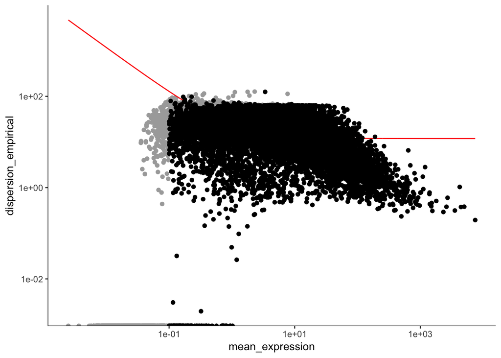

```r
disp_table <- dispersionTable(cds)
unsup_clustering_genes <- subset(disp_table, mean_expression >= 0.1)
cds <- setOrderingFilter(cds, unsup_clustering_genes$gene_id)
plot_ordering_genes(cds)
```

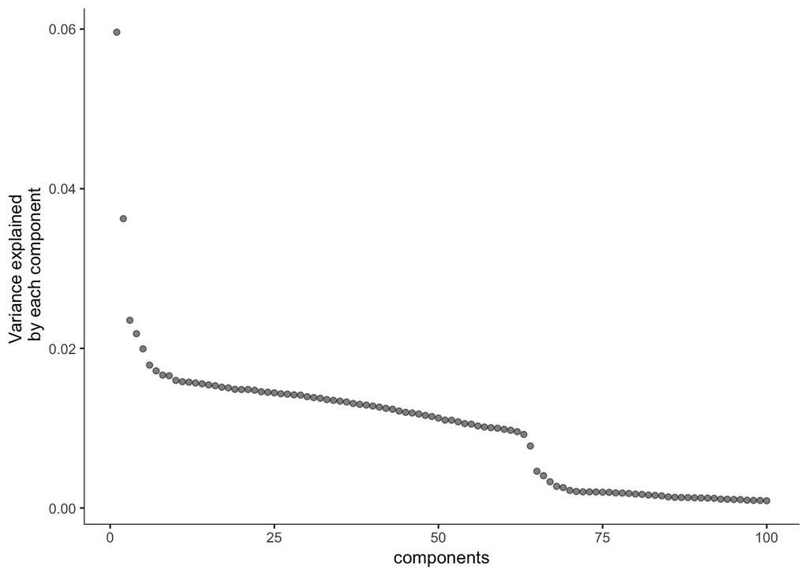

```r
plot_pc_variance_explained(cds, return_all = F) # norm_method='log'
```

```r
cds <- reduceDimension(cds, max_components = 2, num_dim = 6,
                        reduction_method = 'tSNE', verbose = T)
cds <- clusterCells(cds, num_clusters = 4)
```

```
## Distance cutoff calculated to 0.6206275
```

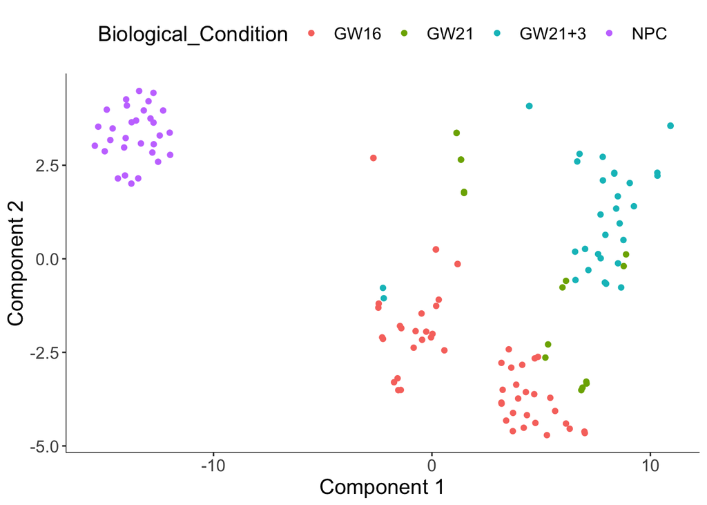

```r
plot_cell_clusters(cds, 1, 2, color = "Biological_Condition")
```

```r
table(pData(cds)$Biological_Condition)
```

```
##
##   GW16   GW21 GW21+3    NPC
##     52     16     32     30
```

可以看到，GW21 也是被打散在其它分组里面。

## 排除干扰因素后聚类

跟前面的质控步骤一样，所谓的干扰因素，也是看自己对数据集的认识情况来自己摸索的，比如我们这里

```r
tmp=pData(cds)
fivenum(tmp[,1])
```

```
## [1]    91616   232899   892209  8130850 14477100
```

```r
fivenum(tmp[,30])
```

```
## [1] 1418.0 2961.0 3841.5 5381.0 8221.0
```

```r
colnames(tmp)
```

```
##  [1] "NREADS"                          "NALIGNED"
##  [3] "RALIGN"                          "TOTAL_DUP"
##  [5] "PRIMER"                          "INSERT_SZ"
##  [7] "INSERT_SZ_STD"                   "COMPLEXITY"
##  [9] "NDUPR"                           "PCT_RIBOSOMAL_BASES"
## [11] "PCT_CODING_BASES"                "PCT_UTR_BASES"
## [13] "PCT_INTRONIC_BASES"              "PCT_INTERGENIC_BASES"
## [15] "PCT_MRNA_BASES"                  "MEDIAN_CV_COVERAGE"
## [17] "MEDIAN_5PRIME_BIAS"              "MEDIAN_3PRIME_BIAS"
## [19] "MEDIAN_5PRIME_TO_3PRIME_BIAS"    "sample_id.x"
## [21] "Lane_ID"                         "LibraryName"
## [23] "avgLength"                       "spots"
## [25] "Biological_Condition"            "Coverage_Type"
## [27] "Cluster1"                        "Cluster2"
## [29] "Size_Factor"                     "num_genes_expressed"
## [31] "Cluster"                         "peaks"
## [33] "halo"                            "delta"
## [35] "rho"                             "nearest_higher_density_neighbor"
```

```r
# 放在 residualModelFormulaStr 里面的是需要去除的
cds <- reduceDimension(cds, max_components = 2, num_dim = 2,
                        reduction_method = 'tSNE',
                        residualModelFormulaStr = "~Biological_Condition + num_genes_expressed",
                        verbose = T)
cds <- clusterCells(cds, num_clusters = 2)
```

```
## Distance cutoff calculated to 0.6762457
```

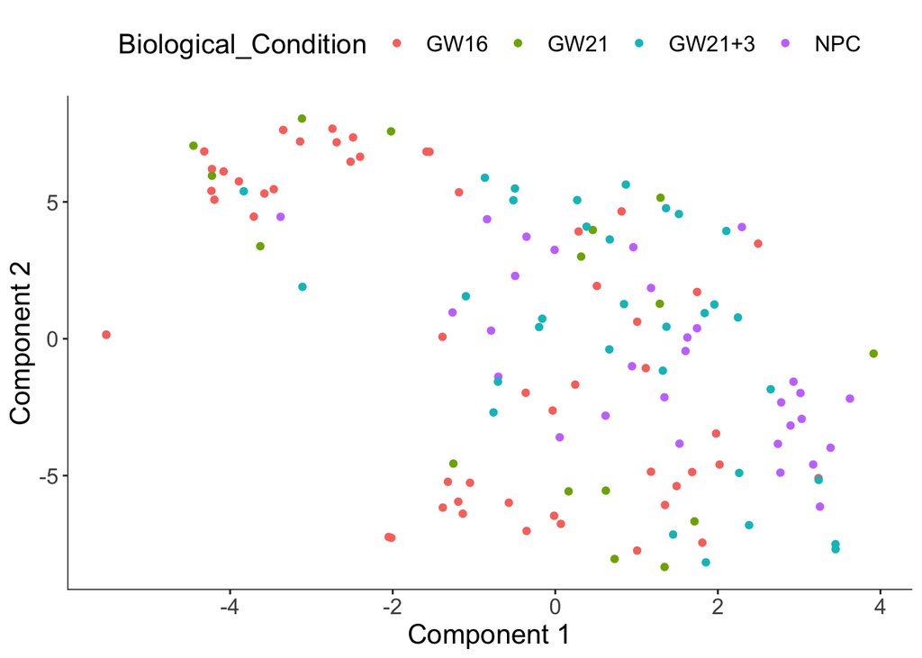

```r
plot_cell_clusters(cds, 1, 2, color = "Biological_Condition")
```

```r
## 上面去除了Biological_Condition，所以接下来聚类它们就被打散了。

cds <- reduceDimension(cds, max_components = 2, num_dim = 2,
                        reduction_method = 'tSNE',
                        residualModelFormulaStr = "~NREADS + num_genes_expressed",
                        verbose = T)
cds <- clusterCells(cds, num_clusters = 2)
```

```
## Distance cutoff calculated to 0.5443418
```

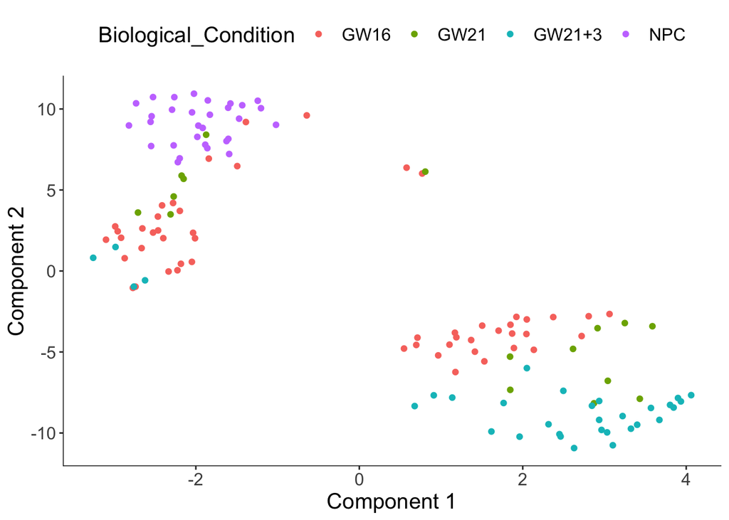

```r
plot_cell_clusters(cds, 1, 2, color = "Biological_Condition")
```

## 差异分析

这个是转录组数据的常规分析了，在单细胞转录组领域也是如此，monocle这个包提供 differentialGeneTest 函数来做差异分析，在我们的例子里面可以是已知的细胞分类，或者是自己推断的聚类结果。

这一步时间会比较久

```r
Sys.time()
```

```
## [1] "2019-02-24 23:15:14 CST"
```

```r
diff_test_res <- differentialGeneTest(cds,
                                      fullModelFormulaStr = "~Biological_Condition")
Sys.time()
```

```
## [1] "2019-02-24 23:34:29 CST"
```

```r
# 可以看到运行耗时

# Select genes that are significant at an FDR < 10%
sig_genes <- subset(diff_test_res, qval < 0.1)
head(sig_genes[,c("gene_short_name", "pval", "qval")] )
```

```
##       gene_short_name         pval         qval
## A1BG             A1BG 6.759792e-04 2.362397e-03
## A2M               A2M 5.659195e-08 5.852474e-07
## AACS             AACS 3.329596e-03 9.677356e-03
## AADAT           AADAT 1.403810e-02 3.422585e-02
## AAGAB           AAGAB 1.717061e-07 1.540937e-06
## AAMP             AAMP 8.820175e-05 3.849301e-04
```

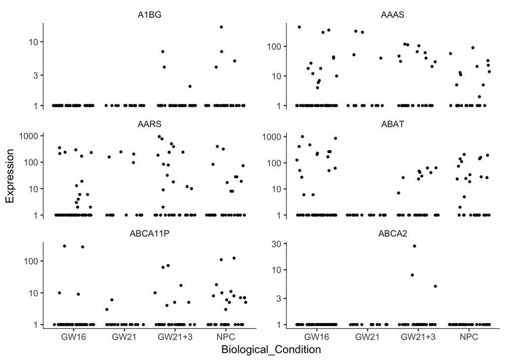

```r
plot_genes_jitter(cds[head(sig_genes$gene_short_name),],
                  grouping = "Biological_Condition", ncol= 2)
```

下面是不同的可视化参数的效果

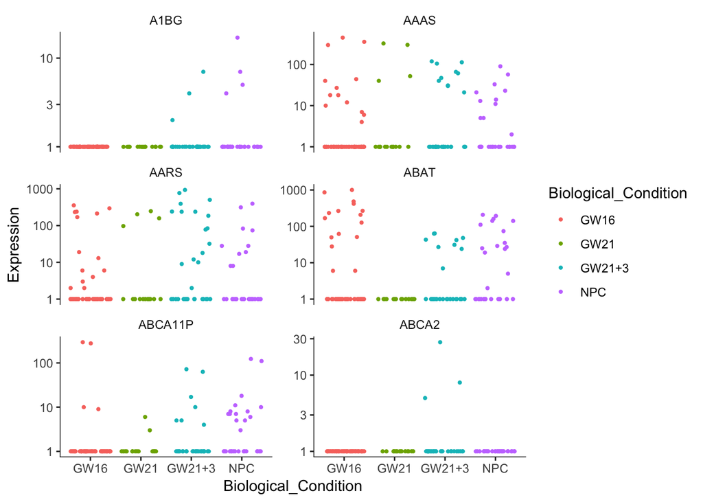

```r
plot_genes_jitter(cds[head(sig_genes$gene_short_name),],
                  grouping = "Biological_Condition",
                  color_by = "Biological_Condition",
                  nrow= 3,
                  ncol = NULL )
```

这个时候可以考虑去选用多个差异分析R包来进行不同的比较，见我在单细胞天地的推文

## 推断发育轨迹

前面介绍的monocle的功能都只能说是中规中矩，而这个推断发育轨迹才是monocle的拿手好戏，也是它荣升为3大R包的核心竞争力。

第一步: 挑选合适的基因. 有多个方法，例如提供已知的基因集，这里选取统计学显著的差异基因列表

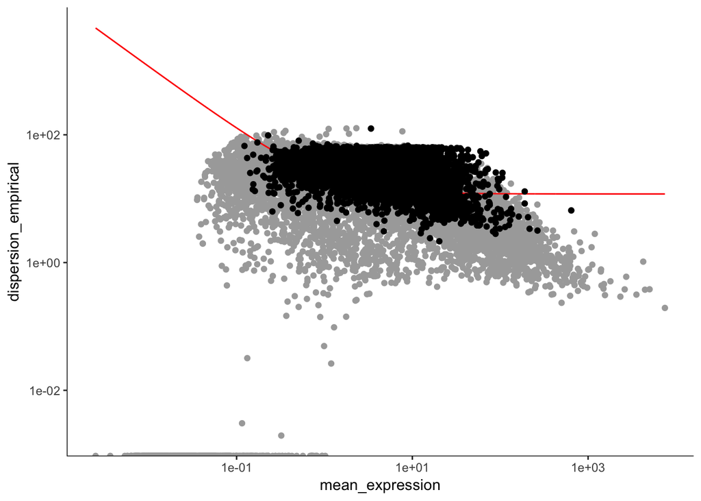

```r
ordering_genes <- row.names (subset(diff_test_res, qval < 0.01))
cds <- setOrderingFilter(cds, ordering_genes)
plot_ordering_genes(cds)
```

```r
cds <- reduceDimension(cds, max_components = 2,
                            method = 'DDRTree')
```

第二步: 降维。降维的目的是为了更好的展示数据。函数里提供了很多种方法, 不同方法的最后展示的图都不太一样, 其中“DDRTree”是Monocle2使用的默认方法

```r
cds <- reduceDimension(cds, max_components = 2,
                            method = 'DDRTree')
```

第三步: 对细胞进行排序

```r
cds <- orderCells(cds)
```

最后两个可视化函数，对结果进行可视化

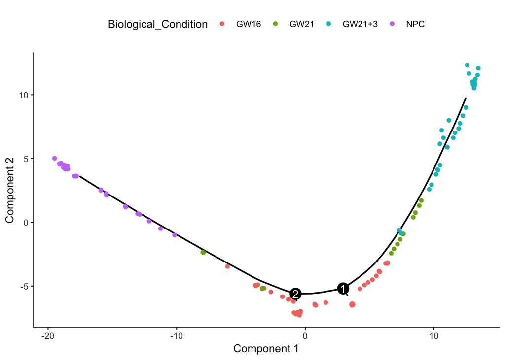

```r
plot_cell_trajectory(cds, color_by = "Biological_Condition")
```

可以很明显看到细胞的发育轨迹，正好对应 pluripotent stem cells 分化而成的 neural progenitor cells (“NPC”) ，还有 “GW16” and “GW21” ，“GW21+3” 这种孕期细胞。

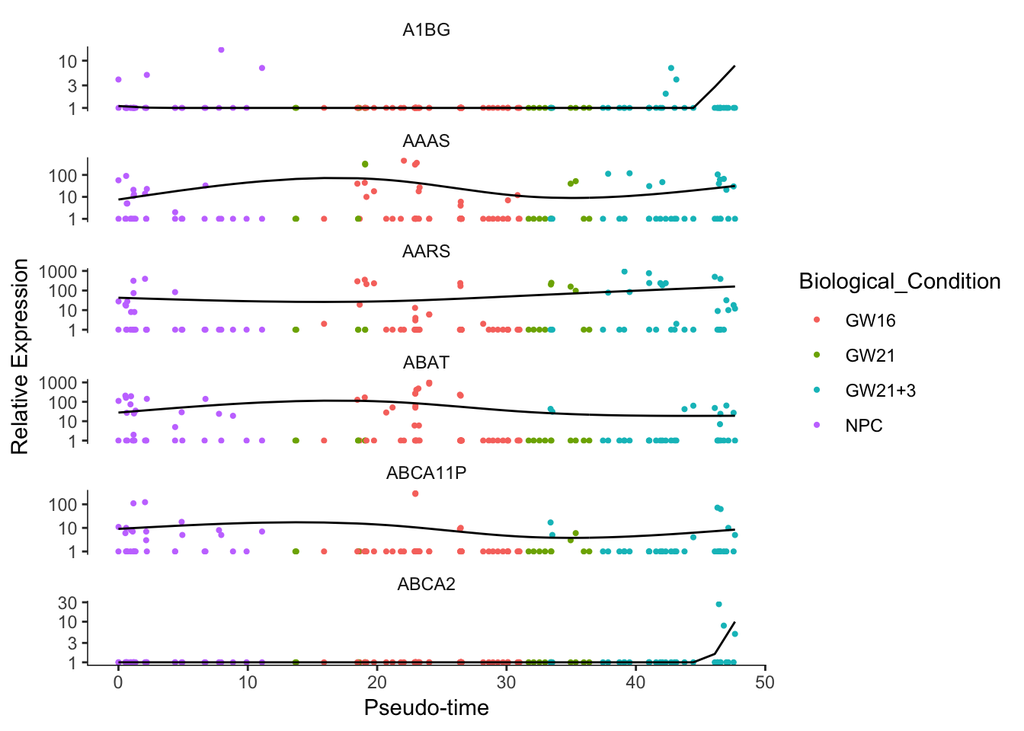

```r
plot_genes_in_pseudotime(cds[head(sig_genes$gene_short_name),],
                         color_by = "Biological_Condition")
```

最开始挑选合适基因，除了我们演示的找统计学显著的差异表达基因这个方法外，还可以于已知的标记基因，主要是基于生物学背景知识。

如果是已知基因列表，就需要自己读取外包文件，导入R里面来分析。